# Case Studies in R

Jayoda

2024-12-08

## Module 01

# Intro to RStudio

install.packages(“palmerpenguins”)

```r
library("palmerpenguins")
summary(penguins)
```

```
##       species          island    bill_length_mm  bill_depth_mm
##  Adelie   :152   Biscoe   :168   Min.   :32.10   Min.   :13.10
##  Chinstrap: 68   Dream    :124   1st Qu.:39.23   1st Qu.:15.60
##  Gentoo   :124   Torgersen: 52   Median :44.45   Median :17.30
##                                  Mean   :43.92   Mean   :17.15
##                                  3rd Qu.:48.50   3rd Qu.:18.70
##                                  Max.   :59.60   Max.   :21.50
##                                  NA's   :2       NA's   :2
##  flipper_length_mm  body_mass_g       sex           year
##  Min.   :172.0     Min.   :2700   female:165   Min.   :2007
##  1st Qu.:190.0     1st Qu.:3550   male  :168   1st Qu.:2007
##  Median :197.0     Median :4050   NA's  : 11   Median :2008
##  Mean   :200.9     Mean   :4202                Mean   :2008
##  3rd Qu.:213.0     3rd Qu.:4750                3rd Qu.:2009
##  Max.   :231.0     Max.   :6300                Max.   :2009
##  NA's   :2         NA's   :2
```

```r
View(penguins)
```

```r
library(ggplot2)
```

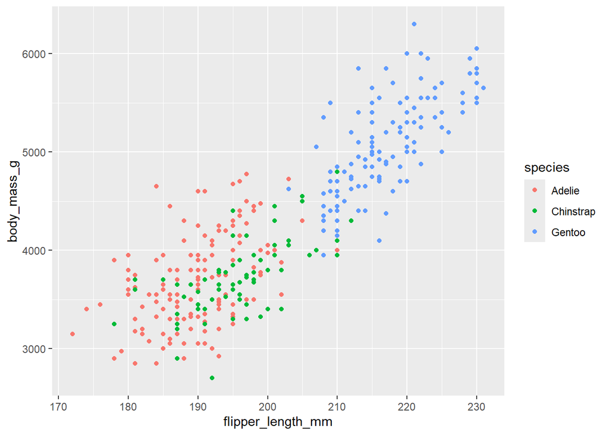

```r
ggplot(data = penguins, aes(x = flipper_length_mm, y = body_mass_g)) + geom_point(aes(color = species))
```

## ————————————————————————————————————————————————-

## Module 02

# Operators and calculations

```r
# our first calculations

quarter_1_sales <- 35657.98
quarter_2_sales <- 43810.55
midyear_sales <- quarter_1_sales + quarter_2_sales

midyear_sales
```

```
## [1] 79468.53
```

```r
yearend_sales <- midyear_sales * 2

yearend_sales
```

```
## [1] 158937.1
```

[output not shown]

# Use pipes to nest code

- ToothGrowth Dataset case study

```r
data("ToothGrowth")
View(ToothGrowth)
```

install.packages(“dplyr”)

```r
filtered_tg <- filter(ToothGrowth, dose == 0.5)
filtered_tg
```

```
##     len supp dose
## 1   4.2   VC  0.5
## 2  11.5   VC  0.5
## 3   7.3   VC  0.5
## 4   5.8   VC  0.5
## 5   6.4   VC  0.5
## 6  10.0   VC  0.5
## 7  11.2   VC  0.5
## 8  11.2   VC  0.5
## 9   5.2   VC  0.5
## 10  7.0   VC  0.5
## 11 15.2   OJ  0.5
## 12 21.5   OJ  0.5
## 13 17.6   OJ  0.5
## 14  9.7   OJ  0.5
## 15 14.5   OJ  0.5
## 16 10.0   OJ  0.5
## 17  8.2   OJ  0.5
## 18  9.4   OJ  0.5
## 19 16.5   OJ  0.5
## 20  9.7   OJ  0.5
```

```r
arrange(filtered_tg, len)
```

```
##     len supp dose
## 1   4.2   VC  0.5
## 2   5.2   VC  0.5
## 3   5.8   VC  0.5
## 4   6.4   VC  0.5
## 5   7.0   VC  0.5
## 6   7.3   VC  0.5
## 7   8.2   OJ  0.5
## 8   9.4   OJ  0.5
## 9   9.7   OJ  0.5
## 10  9.7   OJ  0.5
## 11 10.0   VC  0.5
## 12 10.0   OJ  0.5
## 13 11.2   VC  0.5
## 14 11.2   VC  0.5
## 15 11.5   VC  0.5
## 16 14.5   OJ  0.5
## 17 15.2   OJ  0.5
## 18 16.5   OJ  0.5
## 19 17.6   OJ  0.5
## 20 21.5   OJ  0.5
```

```r
arrange(filter(ToothGrowth, dose == 0.5), len)
```

```
##     len supp dose
## 1   4.2   VC  0.5
## 2   5.2   VC  0.5
## 3   5.8   VC  0.5
## 4   6.4   VC  0.5
## 5   7.0   VC  0.5
## 6   7.3   VC  0.5
## 7   8.2   OJ  0.5
## 8   9.4   OJ  0.5
## 9   9.7   OJ  0.5
## 10  9.7   OJ  0.5
## 11 10.0   VC  0.5
## 12 10.0   OJ  0.5
## 13 11.2   VC  0.5
## 14 11.2   VC  0.5
## 15 11.5   VC  0.5
## 16 14.5   OJ  0.5
## 17 15.2   OJ  0.5
## 18 16.5   OJ  0.5
## 19 17.6   OJ  0.5
## 20 21.5   OJ  0.5
```

```r
filtered_toothgrowth <- ToothGrowth %>%
  filter(dose == 0.5) %>%
  arrange(len)
```

```r
filtered_toothgrowth
```

```
##     len supp dose
## 1   4.2   VC  0.5
## 2   5.2   VC  0.5
## 3   5.8   VC  0.5
## 4   6.4   VC  0.5
## 5   7.0   VC  0.5
## 6   7.3   VC  0.5
## 7   8.2   OJ  0.5
## 8   9.4   OJ  0.5
## 9   9.7   OJ  0.5
## 10  9.7   OJ  0.5
## 11 10.0   VC  0.5
## 12 10.0   OJ  0.5
## 13 11.2   VC  0.5
## 14 11.2   VC  0.5
## 15 11.5   VC  0.5
## 16 14.5   OJ  0.5
## 17 15.2   OJ  0.5
## 18 16.5   OJ  0.5
## 19 17.6   OJ  0.5
## 20 21.5   OJ  0.5
```

```r
filtered_toothgrowth <- ToothGrowth %>%
  filter(dose == 0.5) %>%
  group_by(supp) %>%
  summarize(mean_len = mean(len, na.rm = T), .group = "drop")
```

```r
filtered_toothgrowth
```

```
## # A tibble: 2 × 3
##   supp  mean_len .group
##   <fct>    <dbl> <chr>
## 1 OJ       13.2  drop
## 2 VC        7.98 drop
```

## ————————————————————————————————————————————————-

## Module 03

# Working with data frames

- Diamond Dataset case study

```r
library("ggplot2")
```

```r
data("diamonds")
```

```r
View(diamonds)
```

```r
head(diamonds)
```

```
## # A tibble: 6 × 10
##   carat cut       color clarity depth table price     x     y     z
##   <dbl> <ord>     <ord> <ord>   <dbl> <dbl> <int> <dbl> <dbl> <dbl>
## 1  0.23 Ideal     E     SI2      61.5    55   326  3.95  3.98  2.43
## 2  0.21 Premium   E     SI1      59.8    61   326  3.89  3.84  2.31
## 3  0.23 Good      E     VS1      56.9    65   327  4.05  4.07  2.31
## 4  0.29 Premium   I     VS2      62.4    58   334  4.2   4.23  2.63
## 5  0.31 Good      J     SI2      63.3    58   335  4.34  4.35  2.75
## 6  0.24 Very Good J     VVS2     62.8    57   336  3.94  3.96  2.48
```

```r
str(diamonds)
```

```
## tibble [53,940 × 10] (S3: tbl_df/tbl/data.frame)
##  $ carat  : num [1:53940] 0.23 0.21 0.23 0.29 0.31 0.24 0.24 0.26 0.22 0.23 ...
##  $ cut    : Ord.factor w/ 5 levels "Fair"<"Good"<..: 5 4 2 4 2 3 3 3 1 3 ...
##  $ color  : Ord.factor w/ 7 levels "D"<"E"<"F"<"G"<..: 2 2 2 6 7 7 6 5 2 5 ...
##  $ clarity: Ord.factor w/ 8 levels "I1"<"SI2"<"SI1"<..: 2 3 5 4 2 6 7 3 4 5 ...
##  $ depth  : num [1:53940] 61.5 59.8 56.9 62.4 63.3 62.8 62.3 61.9 65.1 59.4 ...
##  $ table  : num [1:53940] 55 61 65 58 58 57 57 55 61 61 ...
##  $ price  : int [1:53940] 326 326 327 334 335 336 336 337 337 338 ...
##  $ x      : num [1:53940] 3.95 3.89 4.05 4.2 4.34 3.94 3.95 4.07 3.87 4 ...
##  $ y      : num [1:53940] 3.98 3.84 4.07 4.23 4.35 3.96 3.98 4.11 3.78 4.05 ...
##  $ z      : num [1:53940] 2.43 2.31 2.31 2.63 2.75 2.48 2.47 2.53 2.49 2.39 ...
```

```r
colnames(diamonds)
```

```
##  [1] "carat"   "cut"     "color"   "clarity" "depth"   "table"   "price"
##  [8] "x"       "y"       "z"
```

```r
library(tidyverse)
```

```r
mutate(diamonds, carat_2=carat*100)
```

```
## # A tibble: 53,940 × 11
##    carat cut       color clarity depth table price     x     y     z carat_2
##    <dbl> <ord>     <ord> <ord>   <dbl> <dbl> <int> <dbl> <dbl> <dbl>   <dbl>
##  1  0.23 Ideal     E     SI2      61.5    55   326  3.95  3.98  2.43      23
##  2  0.21 Premium   E     SI1      59.8    61   326  3.89  3.84  2.31      21
##  3  0.23 Good      E     VS1      56.9    65   327  4.05  4.07  2.31      23
##  4  0.29 Premium   I     VS2      62.4    58   334  4.2   4.23  2.63      29
##  5  0.31 Good      J     SI2      63.3    58   335  4.34  4.35  2.75      31
##  6  0.24 Very Good J     VVS2     62.8    57   336  3.94  3.96  2.48      24
##  7  0.24 Very Good I     VVS1     62.3    57   336  3.95  3.98  2.47      24
##  8  0.26 Very Good H     SI1      61.9    55   337  4.07  4.11  2.53      26
##  9  0.22 Fair      E     VS2      65.1    61   337  3.87  3.78  2.49      22
## 10  0.23 Very Good H     VS1      59.4    61   338  4     4.05  2.39      23
## # ℹ 53,930 more rows
```

[output not shown]

# Transforming data

```r
id <- c(1:10)

name <- c("John Mendes", "Rob Stewart", "Rachel Abrahamson", "Christy Hickman", "Johnson Harper", "Candace Miller", "Carlson Landy", "Pansy Jordan", "Darius Berry", "Claudia Garcia")

job_title <- c("Professional", "Programmer", "Management", "Clerical", "Developer", "Programmer", "Management", "Clerical", "Developer", "Programmer")
```

```r
employee <- data.frame(id, name, job_title)
```

```r
print(employee)
```

```
##    id              name    job_title
## 1   1       John Mendes Professional
## 2   2       Rob Stewart   Programmer
## 3   3 Rachel Abrahamson   Management
## 4   4   Christy Hickman     Clerical
## 5   5    Johnson Harper    Developer
## 6   6    Candace Miller   Programmer
## 7   7     Carlson Landy   Management
## 8   8      Pansy Jordan     Clerical
## 9   9      Darius Berry    Developer
## 10 10    Claudia Garcia   Programmer
```

```r
separate(employee, name, into = c('first_name', 'last_name'), sep = ' ')
```

```
##    id first_name  last_name    job_title
## 1   1       John     Mendes Professional
## 2   2        Rob    Stewart   Programmer
## 3   3     Rachel Abrahamson   Management
## 4   4    Christy    Hickman     Clerical
## 5   5    Johnson     Harper    Developer
## 6   6    Candace     Miller   Programmer
## 7   7    Carlson      Landy   Management
## 8   8      Pansy     Jordan     Clerical
## 9   9     Darius      Berry    Developer
## 10 10    Claudia     Garcia   Programmer
```

```r
first_name <- c("John", "Rob", "Rachel", "Christy", "Johnson", "Candace", "Carlson", "Pansy", "Darius", "Claudia")
last_name <- c("Mendes", "Stewart", "Abrahamson", "Hickman", "Harper", "Miller", "Landy", "Jordan", "Berry", "Garcia")
job_title <- c("Professional", "Programmer", "Management", "Clerical", "Developer", "Programmer", "Management", "Clerical", "Developer", "Programmer")
```

```r
employee <- data.frame(id, first_name, last_name, job_title)
print(employee)
```

```
##    id first_name  last_name    job_title
## 1   1       John     Mendes Professional
## 2   2        Rob    Stewart   Programmer
## 3   3     Rachel Abrahamson   Management
## 4   4    Christy    Hickman     Clerical
## 5   5    Johnson     Harper    Developer
## 6   6    Candace     Miller   Programmer
## 7   7    Carlson      Landy   Management
## 8   8      Pansy     Jordan     Clerical
## 9   9     Darius      Berry    Developer
## 10 10    Claudia     Garcia   Programmer
```

```r
unite(employee, 'name', first_name, last_name, sep = ' ')
```

```
##    id              name    job_title
## 1   1       John Mendes Professional
## 2   2       Rob Stewart   Programmer
## 3   3 Rachel Abrahamson   Management
## 4   4   Christy Hickman     Clerical
## 5   5    Johnson Harper    Developer
## 6   6    Candace Miller   Programmer
## 7   7     Carlson Landy   Management
## 8   8      Pansy Jordan     Clerical
## 9   9      Darius Berry    Developer
## 10 10    Claudia Garcia   Programmer
```

```r
View(penguins)
```

```r
penguins %>%
  mutate(body_mass_kg = body_mass_g/1000)
```

```
## # A tibble: 344 × 9
##    species island    bill_length_mm bill_depth_mm flipper_length_mm body_mass_g
##    <fct>   <fct>              <dbl>         <dbl>             <int>       <int>
##  1 Adelie  Torgersen           39.1          18.7               181        3750
##  2 Adelie  Torgersen           39.5          17.4               186        3800
##  3 Adelie  Torgersen           40.3          18                 195        3250
##  4 Adelie  Torgersen           NA            NA                  NA          NA
##  5 Adelie  Torgersen           36.7          19.3               193        3450
##  6 Adelie  Torgersen           39.3          20.6               190        3650
##  7 Adelie  Torgersen           38.9          17.8               181        3625
##  8 Adelie  Torgersen           39.2          19.6               195        4675
##  9 Adelie  Torgersen           34.1          18.1               193        3475
## 10 Adelie  Torgersen           42            20.2               190        4250
## # ℹ 334 more rows
## # ℹ 3 more variables: sex <fct>, year <int>, body_mass_kg <dbl>
```

```r
penguins %>%
  mutate(body_mass_kg = body_mass_g/1000, flipper_length_m = flipper_length_mm/1000)
```

```
## # A tibble: 344 × 10
##    species island    bill_length_mm bill_depth_mm flipper_length_mm body_mass_g
##    <fct>   <fct>              <dbl>         <dbl>             <int>       <int>
##  1 Adelie  Torgersen           39.1          18.7               181        3750
##  2 Adelie  Torgersen           39.5          17.4               186        3800
##  3 Adelie  Torgersen           40.3          18                 195        3250
##  4 Adelie  Torgersen           NA            NA                  NA          NA
##  5 Adelie  Torgersen           36.7          19.3               193        3450
##  6 Adelie  Torgersen           39.3          20.6               190        3650
##  7 Adelie  Torgersen           38.9          17.8               181        3625
##  8 Adelie  Torgersen           39.2          19.6               195        4675
##  9 Adelie  Torgersen           34.1          18.1               193        3475
## 10 Adelie  Torgersen           42            20.2               190        4250
## # ℹ 334 more rows
## # ℹ 4 more variables: sex <fct>, year <int>, body_mass_kg <dbl>,
## #   flipper_length_m <dbl>
```

[output not shown]

# Enhancing visualizations in R

`` ## Warning: Removed 2 rows containing missing values or values outside the scale range ## (`geom_point()`). ``

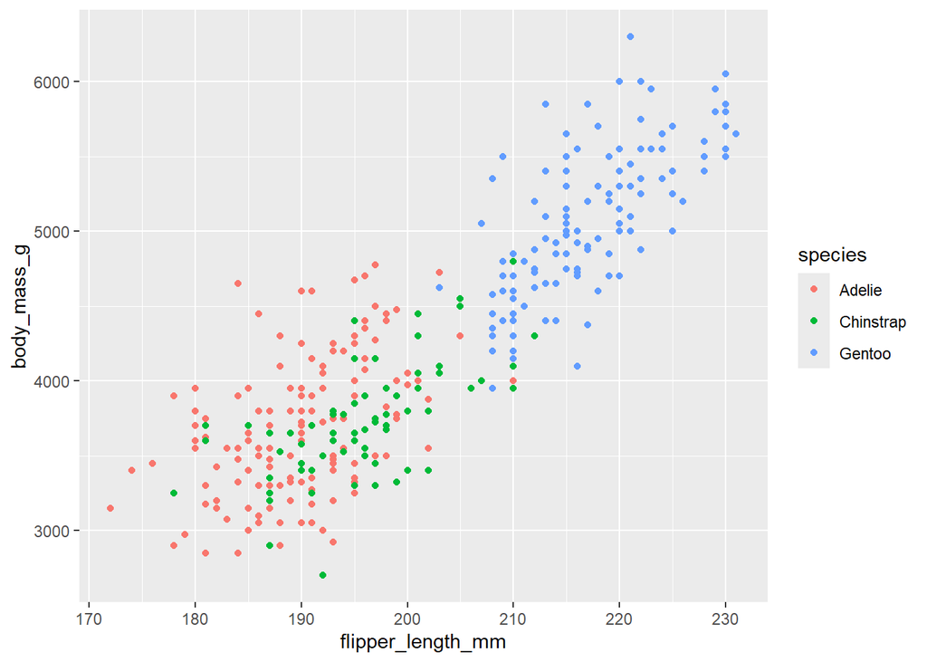

`` ## Warning: Removed 2 rows containing missing values or values outside the scale range ## (`geom_point()`). ``

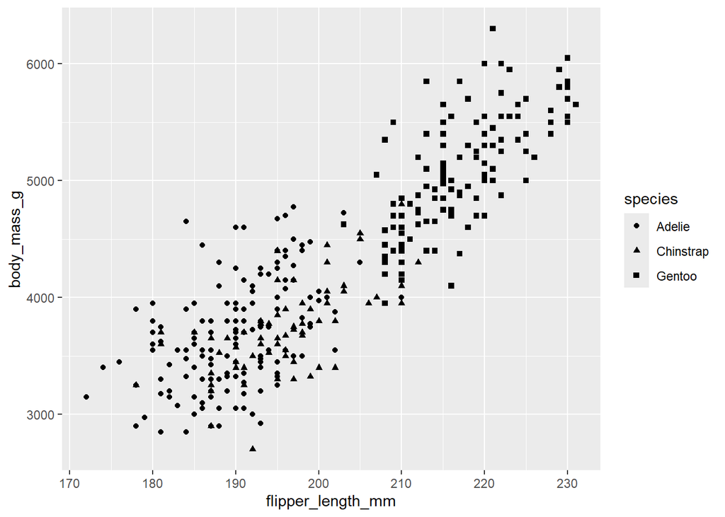

`` ## Warning: Removed 2 rows containing missing values or values outside the scale range ## (`geom_point()`). ``

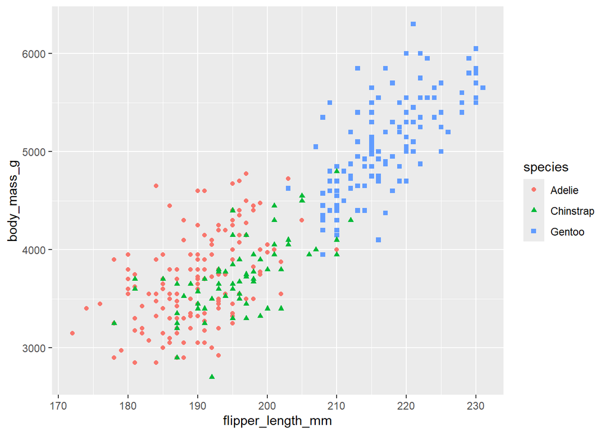

`## Warning: Using size for a discrete variable is not advised.`

`` ## Warning: Removed 2 rows containing missing values or values outside the scale range ## (`geom_point()`). ``

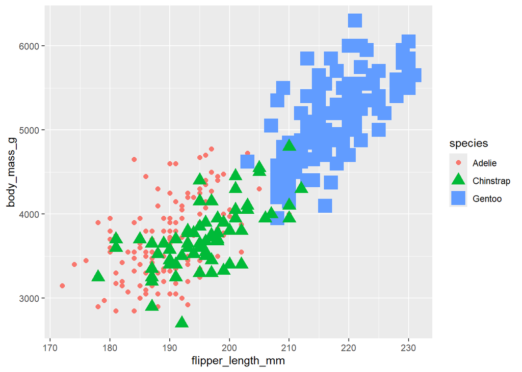

`## Warning: Using alpha for a discrete variable is not advised.`

`` ## Warning: Removed 2 rows containing missing values or values outside the scale range ## (`geom_point()`). ``

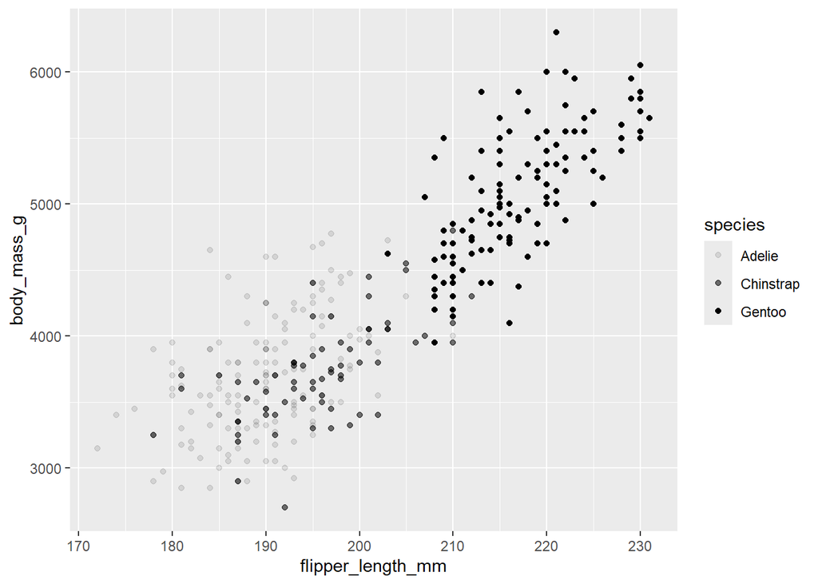

`` ## Warning: Removed 2 rows containing missing values or values outside the scale range ## (`geom_point()`). ``

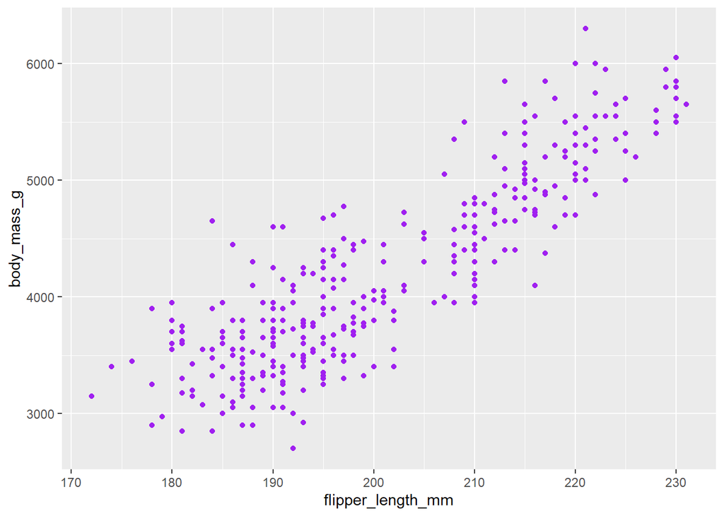

# Doing more with ggplot

```r
library(ggplot2)
library(palmerpenguins)
```

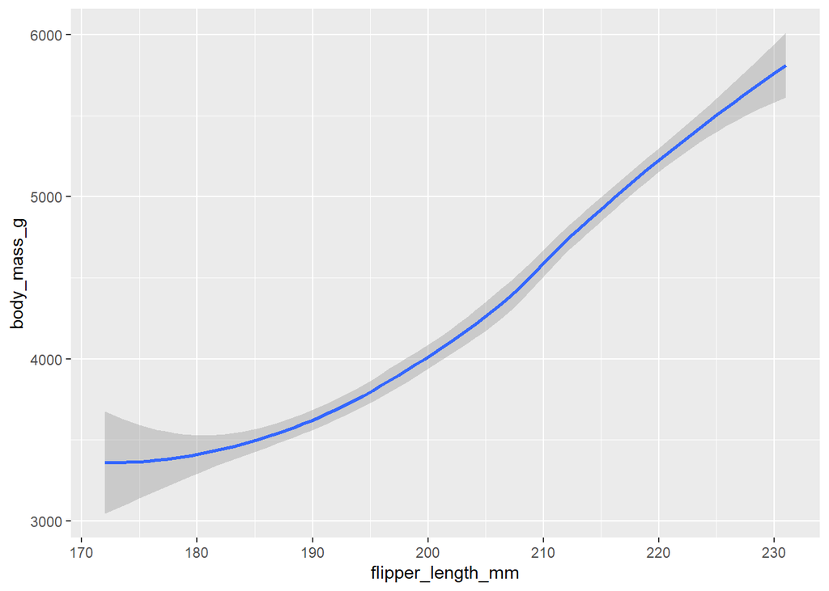

```r
ggplot(data = penguins) +
  geom_smooth(mapping = aes(x=flipper_length_mm, y=body_mass_g))
```

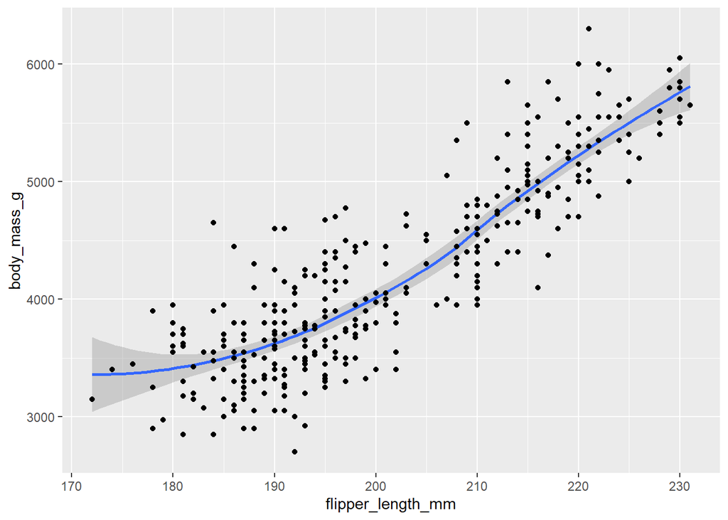

```r
ggplot(data = penguins) +
  geom_smooth(mapping = aes(x=flipper_length_mm, y=body_mass_g)) +
  geom_point(mapping = aes(x=flipper_length_mm, y=body_mass_g))
```

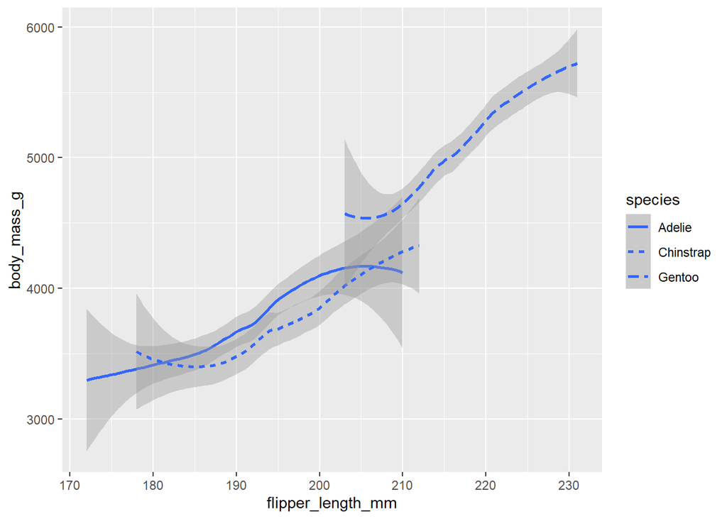

```r
ggplot(data = penguins) +
  geom_smooth(mapping = aes(x=flipper_length_mm, y=body_mass_g, linetype = species))
```